# Clase 10.5. Aplicacion ARIMA(p, d, q) y ARMA(p, q) V2

Benjamin Oliva & Omar Alfaro-Rivera

02/10/2023

# Importamos Datos:

Los datos importados son:

- Pax_Nal: Pasajeros (Salidas) en vuelos nacionales
- Pax_Int: Pasajeros (Salidas) en vuelos internacionales
- Vue_Nal: Vuelos u operaciones (Salidas) en vuelos nacionales
- Vue_Int: Vuelos u operaciones (Salidas) en vuelos internacionales
- Pax_Metro: Pasajeros transportados (Millones) en el SCM
- D_Sep2017: Dummy que toma el valor de 1 en septiembre de 2017
- D_Oct2017: Dummy que toma el valor de 1 en octubre de 2017
- D_Feb2020: Dummy que toma el valor de 1 en febrero de 2020
- D_Mar2020: Dummy que toma el valor de 1 en marzo de 2020
- D_Abr2020: Dummy que toma el valor de 1 en abril de 2020
- D_May2020: Dummy que toma el valor de 1 en mayo de 2020
- D_Jun2020: Dummy que toma el valor de 1 en junio de 2020
- D_Jul2020: Dummy que toma el valor de 1 en julio de 2020
- D_Ene2021: Dummy que toma el valor de 1 en enero de 2021
- D_Mar2021: Dummy que toma el valor de 1 en marzo de 2021
- D_Ene: Dummy que toma el valor de 1 en todos los eneros
- D_Dic: Dummy que toma el valor de 1 en todos los diciembres

Fuente: INEGI, https://www.inegi.org.mx/app/indicadores/?tm=0&t=1090

```r
Datos <- read_excel("Base_Transporte_ARIMA.xlsx", sheet = "Datos", col_names = TRUE)

tail(Datos)
```

```
## # A tibble: 6 × 22
##   Periodo             Pax_Nal Pax_Int Vue_Nal Vue_Int Pax_Metro D_Sep2017
##   <dttm>                <dbl>   <dbl>   <dbl>   <dbl>     <dbl>     <dbl>
## 1 2022-12-01 00:00:00 5456045 2709516   39644   17827      90.0         0
## 2 2023-01-01 00:00:00 5058367 2533314   38226   17747      87.3         0
## 3 2023-02-01 00:00:00 4515723 2277995   33571   15756      86.7         0
## 4 2023-03-01 00:00:00 5287795 2555185   37190   17796      99.4         0
## 5 2023-04-01 00:00:00 5428414 2302621   37443   16325      86.6         0
## 6 2023-05-01 00:00:00 5351191 2161952   37841   15519      96.5         0
## # ℹ 15 more variables: D_Oct2017 <dbl>, D_Feb2020 <dbl>, D_Mar2020 <dbl>,
## #   D_Abr2020 <dbl>, D_May2020 <dbl>, D_Jun2020 <dbl>, D_Jul2020 <dbl>,
## #   D_Ene2021 <dbl>, D_Mar2021 <dbl>, D_Ene <dbl>, D_Feb <dbl>, D_Jul <dbl>,
## #   D_Dic <dbl>, D_Ene2022 <dbl>, D_Feb2022 <dbl>
```

# Funciones que extrae y grafica las raices del polinomio caracteristico

```r
source("arroots.R")
source("maroots.R")
source("plot.armaroots.R")
```

# Conversion a series de tiempo:

```r
Pax_Nal <- ts(Datos$Pax_Nal,
              start = c(2000, 1),
              freq = 12)

LPax_Nal <- ts(log(Datos$Pax_Nal),
               start = c(2000, 1),
               freq = 12)

DLPax_Nal <- ts(log(Datos$Pax_Nal) - lag(log(Datos$Pax_Nal), 1),
                start = c(2000, 1),
                freq = 12)

DLPax_Nal_S <- diff(DLPax_Nal, 12)

D_Feb2020   <- ts(Datos$D_Feb2020,
                start = c(2000, 1),
                freq = 12)

D_Mar2020   <- ts(Datos$D_Mar2020,
                start = c(2000, 1),
                freq = 12)

D_Abr2020   <- ts(Datos$D_Abr2020,
                start = c(2000, 1),
                freq = 12)

D_May2020   <- ts(Datos$D_May2020,
                start = c(2000, 1),
                freq = 12)

D_Jun2020   <- ts(Datos$D_Jun2020,
                start = c(2000, 1),
                freq = 12)

D_Jul2020 <- ts(Datos$D_Jul2020,
                start = c(2000, 1),
                freq = 12)

D_Ene2021 <- ts(Datos$D_Ene2021,
                start = c(2000, 1),
                freq = 12)

D_Mar2021 <- ts(Datos$D_Mar2021,
                start = c(2000, 1),
                freq = 12)

D_Ene <- ts(Datos$D_Ene,
            start = c(2000, 1),
            freq = 12)

D_Feb <- ts(Datos$D_Feb,
            start = c(2000, 1),
            freq = 12)

D_Jul <- ts(Datos$D_Jul,
            start = c(2000, 1),
            freq = 12)

D_Dic <- ts(Datos$D_Dic,
            start = c(2000, 1),
            freq = 12)
```

# Graficas:

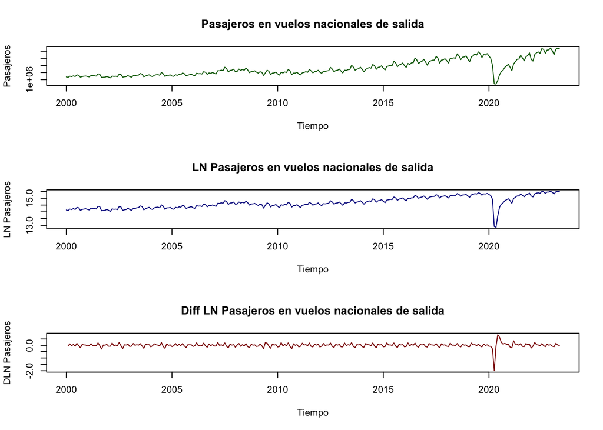

# Visualizar estacionalidad

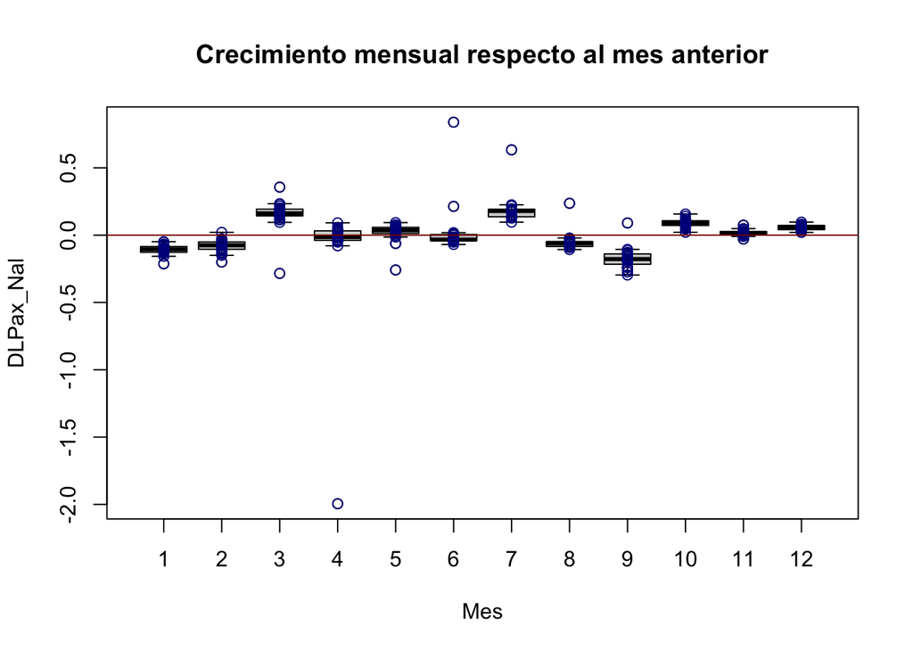

```r
boxplot(DLPax_Nal ~ month(Datos$Periodo),
        xlab= "Mes",
        main = "Crecimiento mensual respecto al mes anterior")
points(DLPax_Nal ~ month(Datos$Periodo), col = "darkblue")
abline(h = 0, col = "darkred")
```

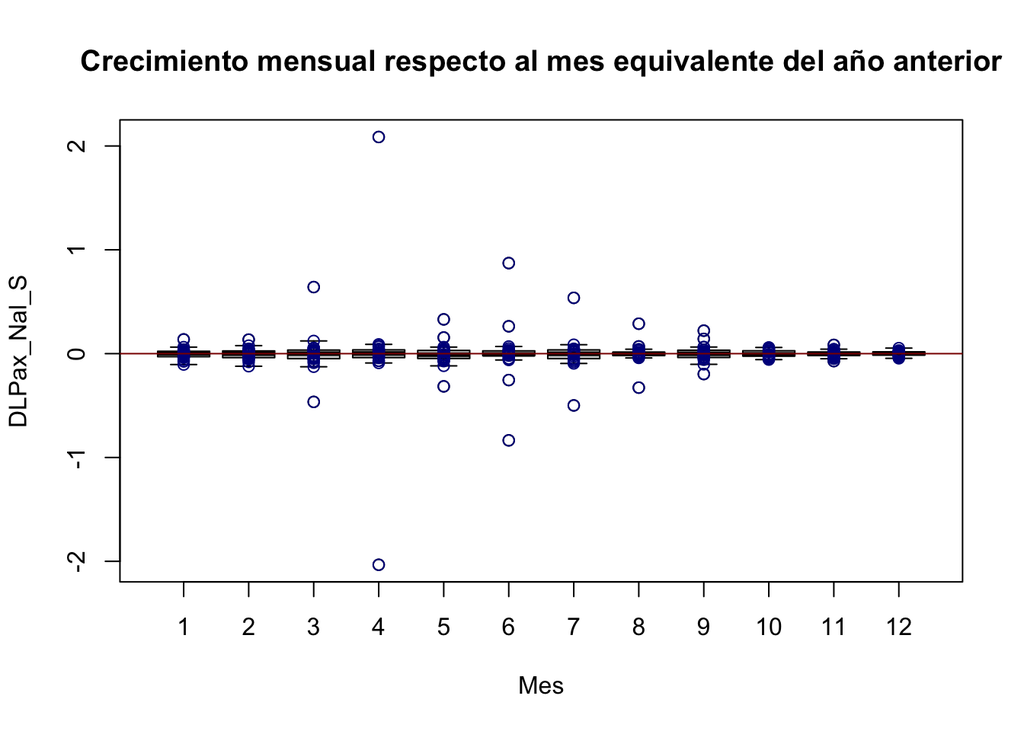

```r
boxplot(DLPax_Nal_S ~ month(Datos$Periodo[-c(1:12)]),
        xlab= "Mes",
        main = "Crecimiento mensual respecto al mes equivalente del año anterior")
points(DLPax_Nal_S ~ month(Datos$Periodo)[-c(1:12)], col = "darkblue")
abline(h = 0, col = "darkred")
```

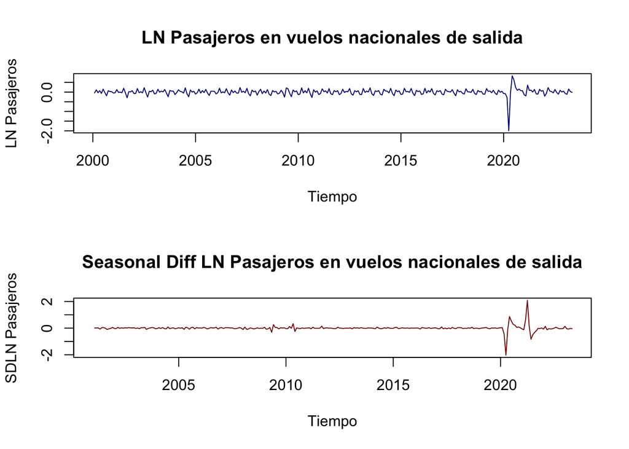

```r
par(mfrow=c(2,1))

plot(DLPax_Nal, xlab = "Tiempo", ylab = "LN Pasajeros",
     main = "LN Pasajeros en vuelos nacionales de salida",
     col = "darkblue")


plot(diff(DLPax_Nal,12), xlab = "Tiempo",  ylab = "SDLN Pasajeros",
     main = "Seasonal Diff LN Pasajeros en vuelos nacionales de salida",
     col = "darkred")
```

```r
par(mfrow=c(1,1))
```

# Funciones que determinan el rezago optimo (que minimiza el criterio de Akaike)

```r
source("Lag_Opt_ARIMA_Exog.R")
source("Lag_Opt_SARIMA_Exog.R")
```

# ARIMA Optimo

```r
dumm_ARIMA = cbind(D_Ene, D_Feb, D_Jul, D_Dic, D_Mar2020, D_Abr2020, D_Jun2020, D_Jul2020, D_Mar2021)

Lag_Opt_ARIMA_Exog( p_max = 6, q_max = 6,
                    X_t = DLPax_Nal,
                    Ex = 1,
                    Z_t = dumm_ARIMA )
```

```
##       Rezago p Rezago q       AIC Optimo
##  [1,]        1        1 -561.4867      0
##  [2,]        1        2 -561.4327      0
##  [3,]        1        3 -573.7566      0
##  [4,]        1        4 -593.7144      0
##  [5,]        1        5 -600.6879      0
##  [6,]        1        6 -609.8023      0
##  [7,]        2        1 -561.8333      0
##  [8,]        2        2 -570.3672      0
##  [9,]        2        3 -621.3838      0
## [10,]        2        4 -615.1356      0
## [11,]        2        5 -685.4830      0
## [12,]        2        6 -684.7904      0
## [13,]        3        1 -540.7461      0
## [14,]        3        2 -568.3680      0
```

[output cut: 22 more lines]

```r
ARIMA_Ex_DLPax_Nal <- arima( DLPax_Nal, c(6,0,6),
                             xreg = dumm_ARIMA,
                             method = "ML" )
ARIMA_Ex_DLPax_Nal
```

```
##
## Call:
## arima(x = DLPax_Nal, order = c(6, 0, 6), xreg = dumm_ARIMA, method = "ML")
##
## Coefficients:
##          ar1      ar2     ar3      ar4     ar5      ar6      ma1      ma2
##       0.0026  -0.0015  0.0026  -0.0008  0.0051  -0.9971  -0.0309  -0.0621
## s.e.  0.0045   0.0049  0.0070   0.0048  0.0043   0.0024   0.0378   0.0292
##           ma3      ma4      ma5     ma6  intercept    D_Ene    D_Feb   D_Jul
##       -0.0863  -0.0025  -0.0486  0.9532     0.0203  -0.1230  -0.1696  0.1436
## s.e.   0.0325   0.0345   0.0379  0.0367     0.0040   0.1009   0.0167  0.0992
##         D_Dic  D_Mar2020  D_Abr2020  D_Jun2020  D_Jul2020  D_Mar2021
##       -0.0001    -0.4714    -1.9748     0.8921     0.4998     0.1747
## s.e.   0.0173     0.0505     0.0500     0.0526     0.0519     0.0497
##
## sigma^2 estimated as 0.002394:  log likelihood = 436.71,  aic = -827.42
```

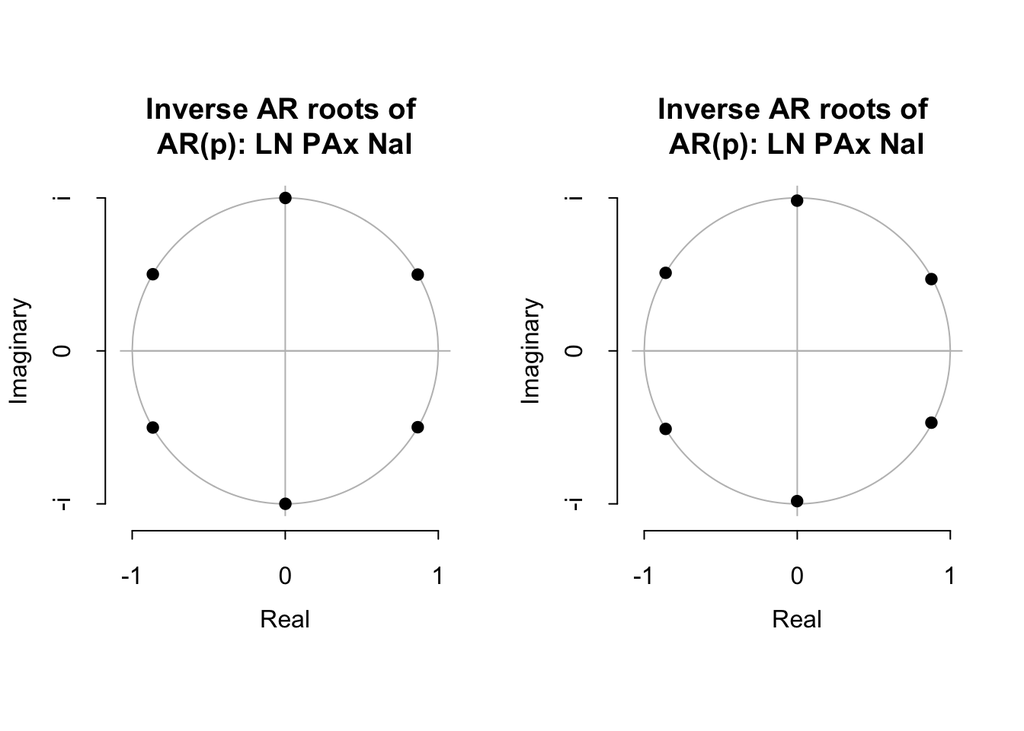

```r
par(mfrow=c(1,2))
plot.armaroots(arroots(ARIMA_Ex_DLPax_Nal),
               main="Inverse AR roots of \nAR(p): LN PAx Nal")
plot.armaroots(maroots(ARIMA_Ex_DLPax_Nal),
               main="Inverse AR roots of \nAR(p): LN PAx Nal")
```

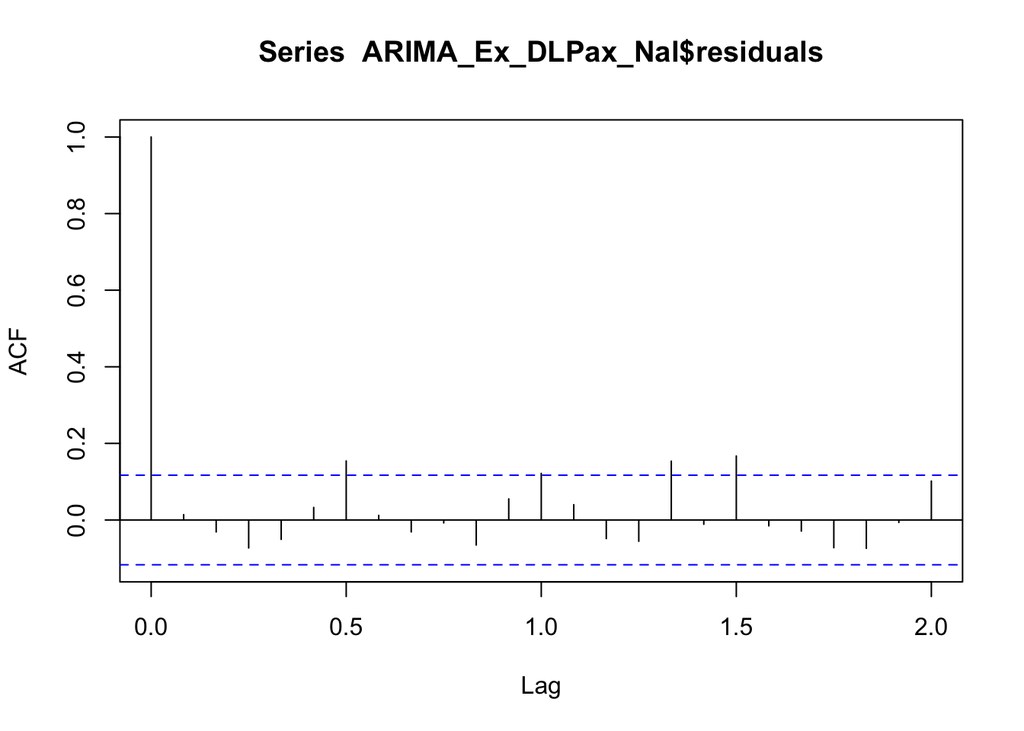

```r
par(mfrow=c(1,1))
acf(ARIMA_Ex_DLPax_Nal$residuals, na.action = na.pass)
```

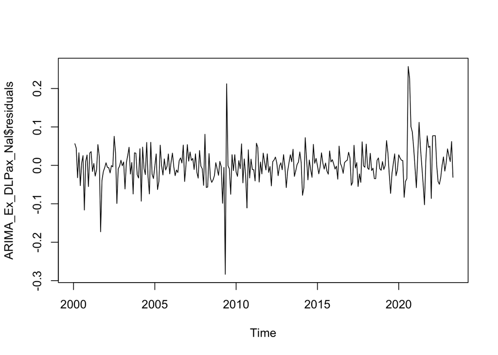

```r
plot(ARIMA_Ex_DLPax_Nal$residuals)
```

# SARIMA optimo

```r
dumm_SARIMA <-cbind(D_Mar2020[-c(1:12)], D_Abr2020[-c(1:12)], D_Jun2020[-c(1:12)], D_Jul2020[-c(1:12)], D_Mar2021[-c(1:12)])

Lag_Opt_SARIMA_Exog(p_max = 4, q_max = 4,
                    P_max = 0, Q_max = 2,
                   X_t = DLPax_Nal_S,
                   Ex = 0)
```

```
##       Rezago p Rezago q Rezago P Rezago Q       AIC Optimo
##  [1,]        1        1        0        0 -108.2900      0
##  [2,]        1        1        0        1 -270.7002      0
##  [3,]        1        1        0        2 -269.4474      0
##  [4,]        1        2        0        0 -144.2849      0
##  [5,]        1        2        0        1 -297.5518      1
##  [6,]        1        2        0        2 -295.7187      0
##  [7,]        1        3        0        0 -143.8260      0
##  [8,]        1        3        0        1 -296.0779      0
##  [9,]        1        3        0        2 -294.2059      0
## [10,]        1        4        0        0 -142.0623      0
## [11,]        1        4        0        1 -295.1759      0
## [12,]        1        4        0        2 -293.3956      0
## [13,]        2        1        0        0 -122.5567      0
## [14,]        2        1        0        1 -285.6091      0
```

[output cut: 34 more lines]

```r
Lag_Opt_SARIMA_Exog(p_max = 4, q_max = 4,
                    P_max = 0, Q_max = 2,
                    X_t = DLPax_Nal_S,
                    Ex = 1,
                    Z_t = dumm_SARIMA)
```

```
##       Rezago p Rezago q Rezago P Rezago Q       AIC Optimo
##  [1,]        1        1        0        0 -248.1283      0
##  [2,]        1        1        0        1 -320.0554      0
##  [3,]        1        1        0        2 -320.2170      0
##  [4,]        1        2        0        0 -274.2981      0
##  [5,]        1        2        0        1 -337.5957      0
##  [6,]        1        2        0        2 -336.2551      0
##  [7,]        1        3        0        0 -273.0151      0
##  [8,]        1        3        0        1 -340.2382      0
##  [9,]        1        3        0        2 -341.0886      0
## [10,]        1        4        0        0 -271.0276      0
## [11,]        1        4        0        1 -341.7559      0
## [12,]        1        4        0        2 -339.3732      0
## [13,]        2        1        0        0 -262.0506      0
## [14,]        2        1        0        1 -334.1995      0
```

[output cut: 34 more lines]

```r
SARIMA_Ex_DLPax_Nal <- arima(DLPax_Nal_S, order = c(4, 0, 4),
                             seasonal = c(0, 0, 2),
                           xreg = dumm_SARIMA,
                           method = "ML")
SARIMA_Ex_DLPax_Nal
```

```
##
## Call:
## arima(x = DLPax_Nal_S, order = c(4, 0, 4), seasonal = c(0, 0, 2), xreg = dumm_SARIMA,
##     method = "ML")
##
## Coefficients:
```

```
##           ar1     ar2     ar3      ar4     ma1      ma2      ma3      ma4
##       -0.7629  0.4831  0.4912  -0.1463  1.4878  -0.0358  -1.3018  -0.6134
## s.e.   0.0795     NaN     NaN   0.0434  0.0559      NaN      NaN      NaN
##          sma1    sma2  intercept  dumm_SARIMA1  dumm_SARIMA2  dumm_SARIMA3
##       -1.0972  0.0977      2e-04        0.5758       -0.3791        0.2666
## s.e.   0.0961  0.0802      5e-04        0.1044        0.0628        0.0675
##       dumm_SARIMA4  dumm_SARIMA5
##             0.0697       -0.7057
## s.e.        0.0561        0.1224
##
## sigma^2 estimated as 0.01171:  log likelihood = 189,  aic = -344.01
```

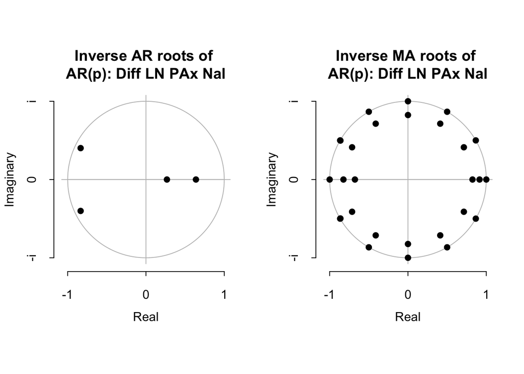

```r
par(mfrow=c(1,2))
plot.armaroots(arroots(SARIMA_Ex_DLPax_Nal),
               main="Inverse AR roots of \nAR(p): Diff LN PAx Nal")
plot.armaroots(maroots(SARIMA_Ex_DLPax_Nal),
               main="Inverse MA roots of \nAR(p): Diff LN PAx Nal")
```

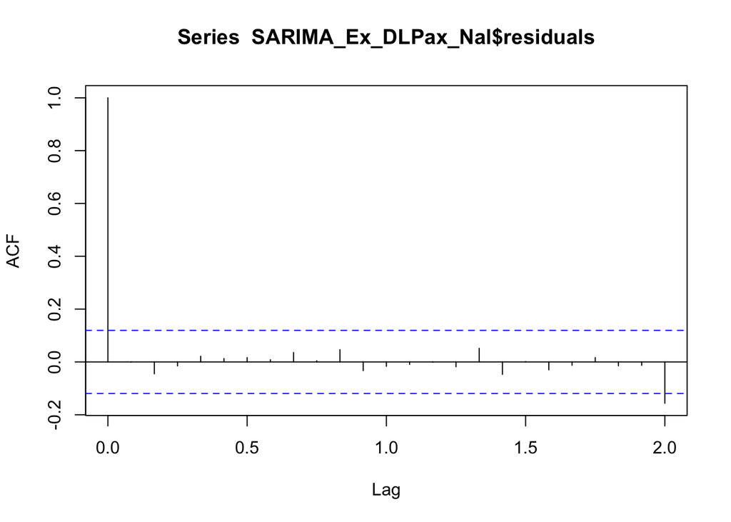

```r
par(mfrow=c(1,1))

acf(SARIMA_Ex_DLPax_Nal$residuals, na.action = na.pass)
```

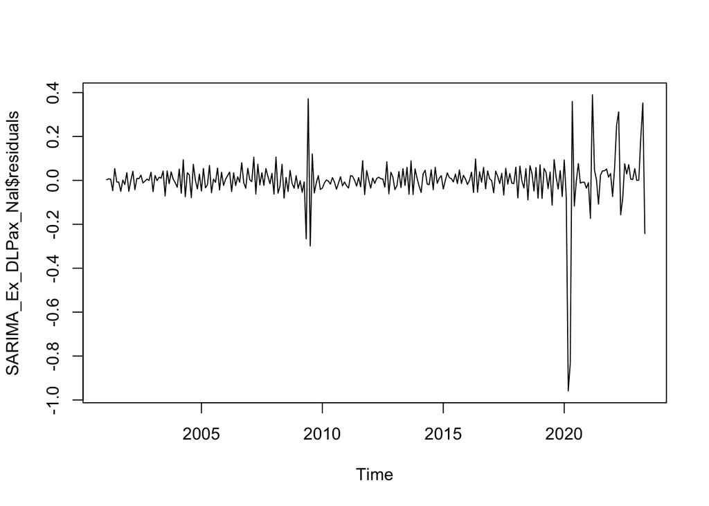

```r
plot(SARIMA_Ex_DLPax_Nal$residuals)
```

## Comparación

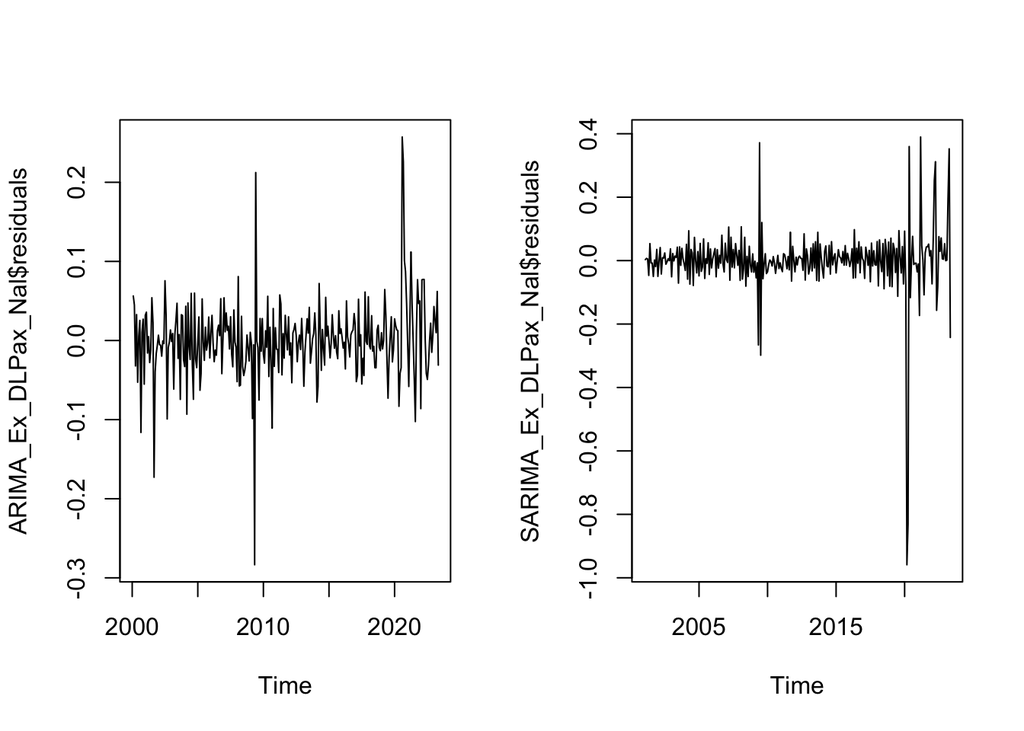

```r
par(mfrow=c(1,2))

plot(ARIMA_Ex_DLPax_Nal$residuals)

plot(SARIMA_Ex_DLPax_Nal$residuals)
```

```r
par(mfrow=c(1,1))
```

# ARIMA auto.arima():

```r
?auto.arima
#auto.arima
```

### Implementación ARIMA:

```r
ARIMA_model = auto.arima(DLPax_Nal,
                         xreg = dumm_ARIMA,
                         seasonal = TRUE)

ARIMA_model
```

```
## Series: DLPax_Nal
## Regression with ARIMA(0,0,1)(1,0,0)[12] errors
##
## Coefficients:
##           ma1    sar1    D_Ene    D_Feb   D_Jul   D_Dic  D_Mar2020  D_Abr2020
##       -0.1316  0.7416  -0.0990  -0.0588  0.1490  0.0570    -0.4583    -2.0743
## s.e.   0.0746  0.0380   0.0431   0.0437  0.0432  0.0428     0.0545     0.0485
##       D_Jun2020  D_Jul2020  D_Mar2021
##          0.8357     0.5603     0.1524
## s.e.     0.0485     0.0549     0.0541
##
## sigma^2 = 0.003649:  log likelihood = 389.38
## AIC=-754.77   AICc=-753.6   BIC=-711.15
```

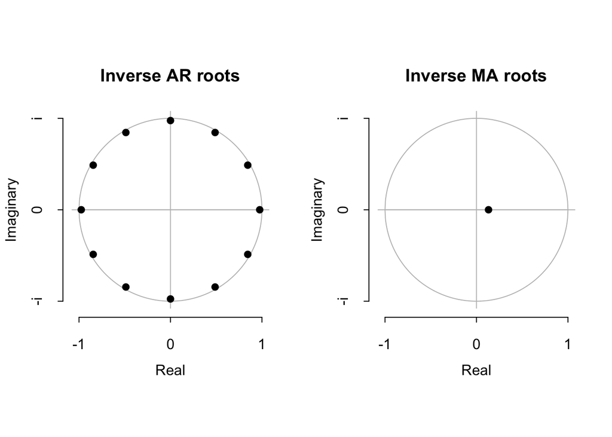

```r
#
plot(ARIMA_model)
```

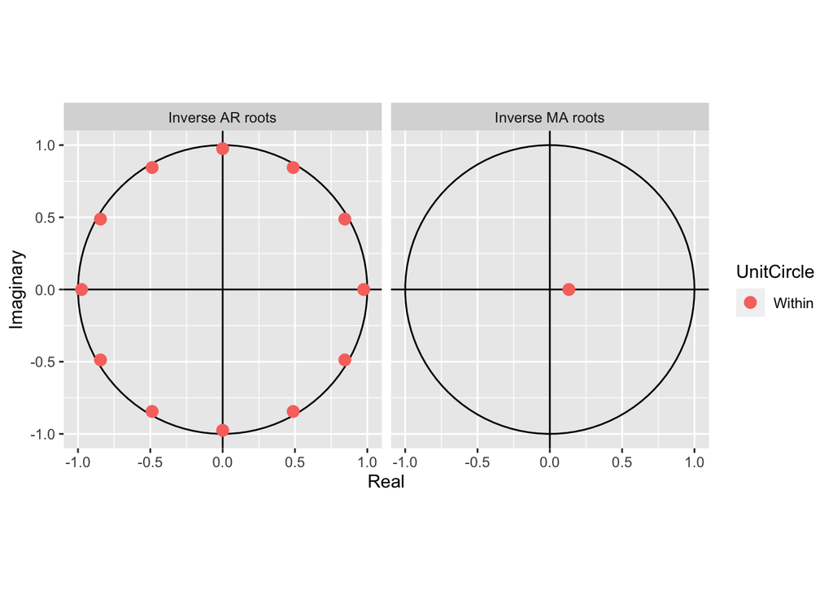

```r
autoplot(ARIMA_model)
```

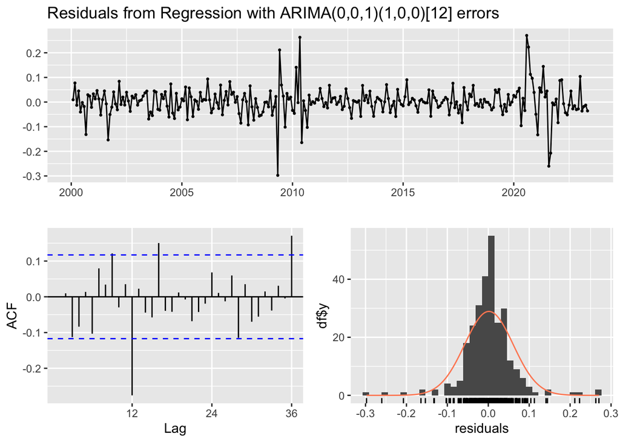

```
##
##  Ljung-Box test
##
## data:  Residuals from Regression with ARIMA(0,0,1)(1,0,0)[12] errors
## Q* = 51.298, df = 22, p-value = 0.0003904
##
## Model df: 2.   Total lags used: 24
```

```r
checkresiduals(ARIMA_model)
```

### Implementación SARIMA:

```r
SARIMA_model = auto.arima(DLPax_Nal_S, xreg =dumm_SARIMA)

SARIMA_model
```

```
## Series: DLPax_Nal_S
## Regression with ARIMA(2,0,0)(1,0,0)[12] errors
##
## Coefficients:
##          ar1      ar2     sar1    xreg1    xreg2   xreg3   xreg4    xreg5
##       0.5353  -0.4152  -0.3517  -0.1374  -1.3678  0.6678  0.3295  -0.4265
## s.e.  0.0702   0.0589   0.0695   0.1514   0.1693  0.1456  0.1318   0.1450
##
## sigma^2 = 0.01971:  log likelihood = 148.91
## AIC=-279.83   AICc=-279.13   BIC=-247.51
```

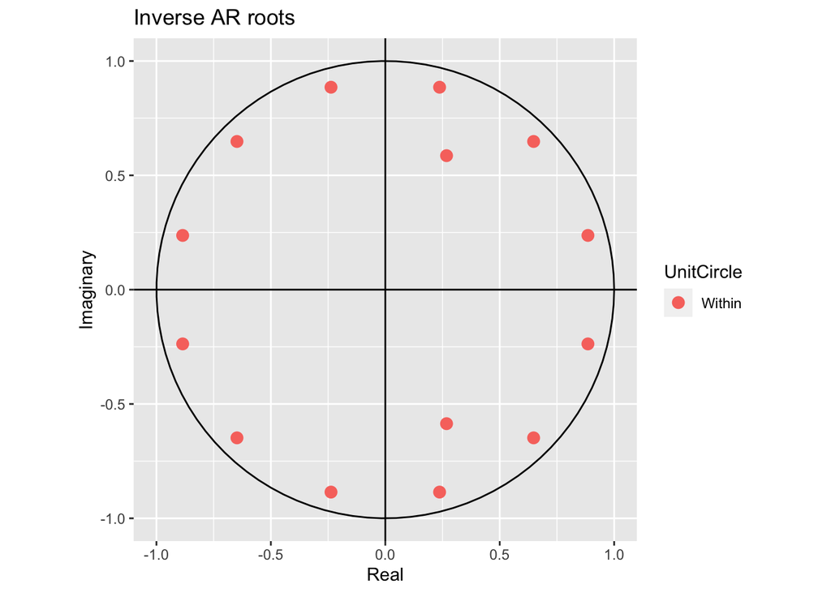

```r
autoplot(SARIMA_model)
```

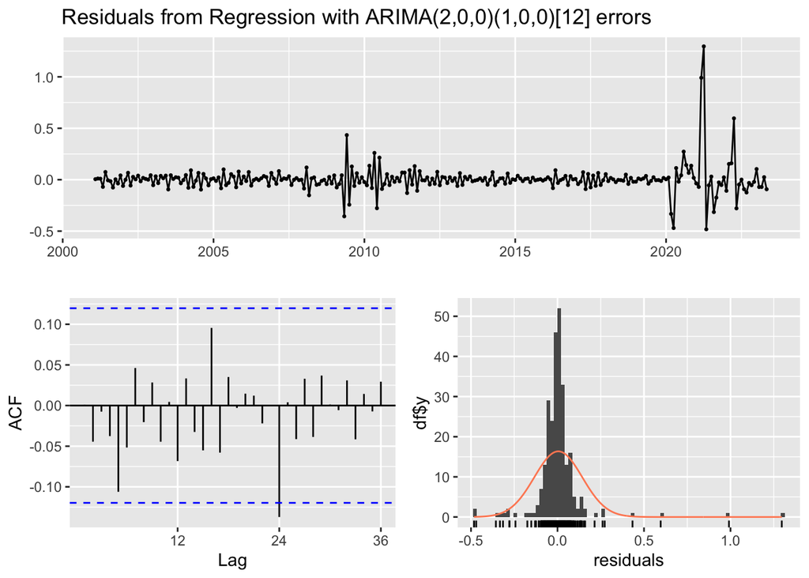

```
##
##  Ljung-Box test
##
## data:  Residuals from Regression with ARIMA(2,0,0)(1,0,0)[12] errors
## Q* = 18.838, df = 21, p-value = 0.5955
##
## Model df: 3.   Total lags used: 24
```

```r
checkresiduals(SARIMA_model)
```

```r
dumm_SARIMA <-cbind(D_Mar2020, D_Abr2020, D_Jun2020, D_Jul2020, D_Mar2021)

SARIMA_model2= auto.arima(LPax_Nal, xreg = dumm_SARIMA)

SARIMA_model2
```

```
## Series: LPax_Nal
## Regression with ARIMA(1,1,1)(2,0,0)[12] errors
##
## Coefficients:
##          ar1     ma1    sar1    sar2  D_Mar2020  D_Abr2020  D_Jun2020
##       0.3292  0.3657  0.3578  0.4224     0.2801    -0.6291     0.6015
## s.e.  0.0796  0.0694  0.0519  0.0535     0.0703     0.0738     0.0750
##       D_Jul2020  D_Mar2021
##          0.3556     0.1012
## s.e.     0.0695     0.0446
##
## sigma^2 = 0.01276:  log likelihood = 212.33
## AIC=-404.66   AICc=-403.84   BIC=-368.31
```

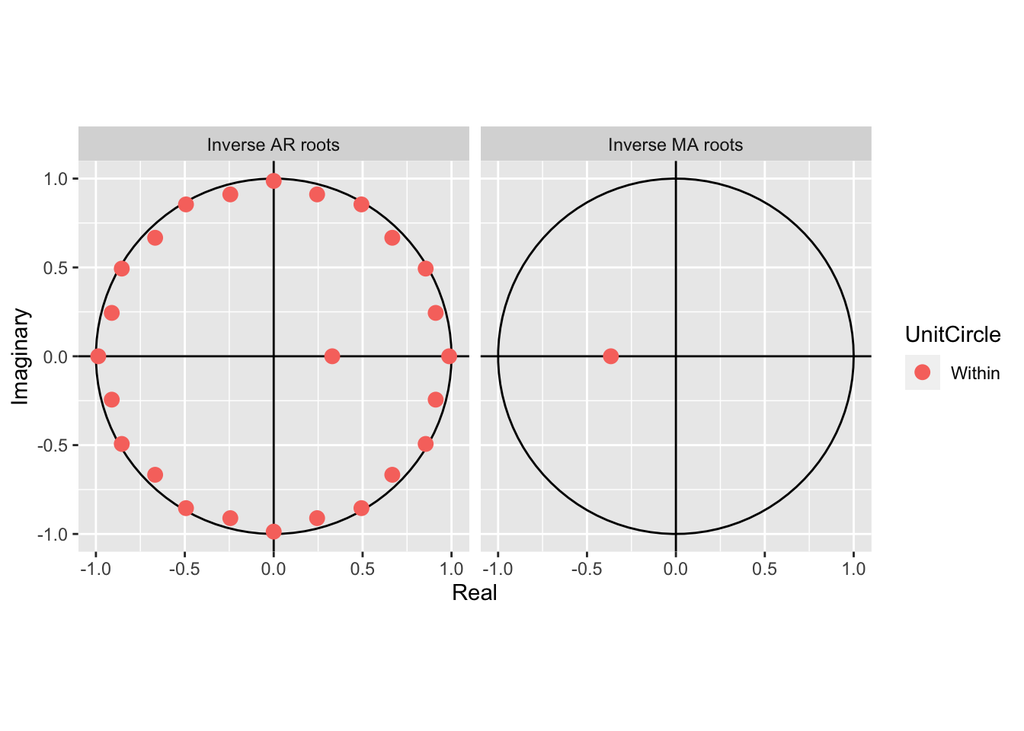

```r
autoplot(SARIMA_model2)
```

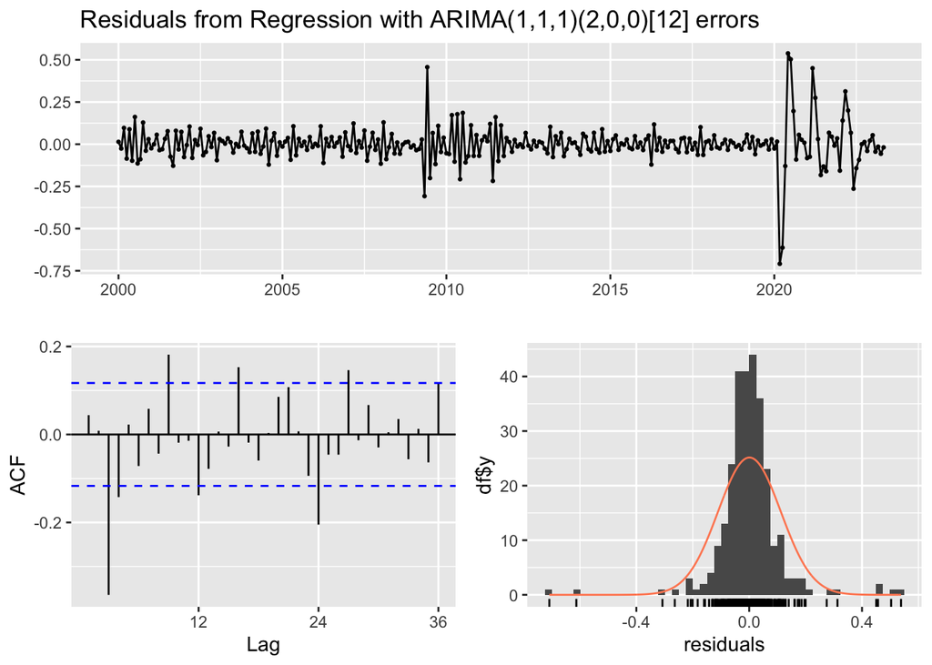

```
##
##  Ljung-Box test
##
## data:  Residuals from Regression with ARIMA(1,1,1)(2,0,0)[12] errors
## Q* = 94.722, df = 20, p-value = 1.095e-11
##
## Model df: 4.   Total lags used: 24
```

```r
checkresiduals(SARIMA_model2)
```

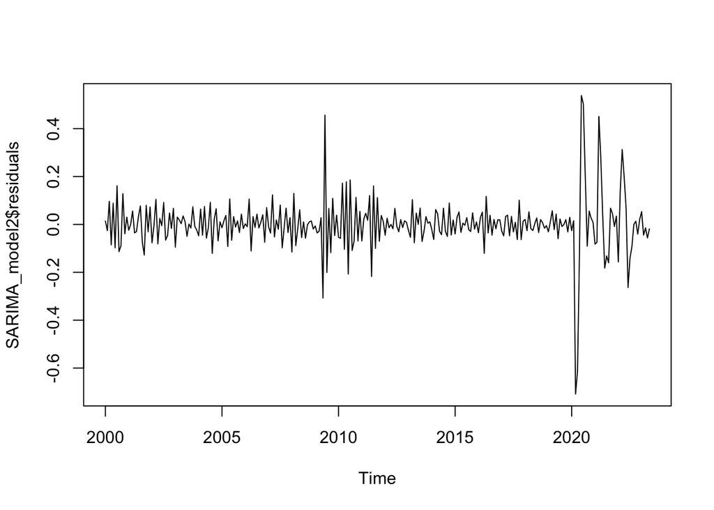

```r
plot(SARIMA_model2$residuals)
```

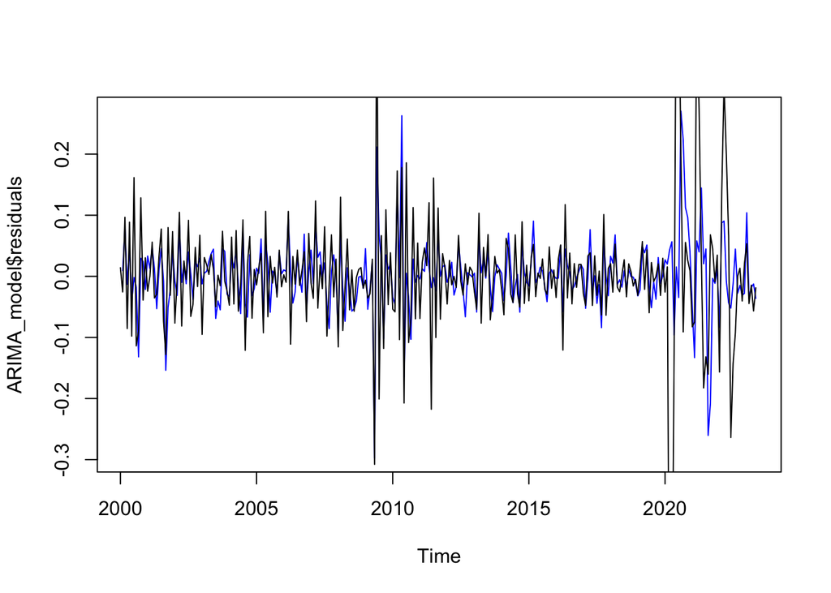

```r
plot(ARIMA_model$residuals, col = "blue")
lines(SARIMA_model2$residuals)
```

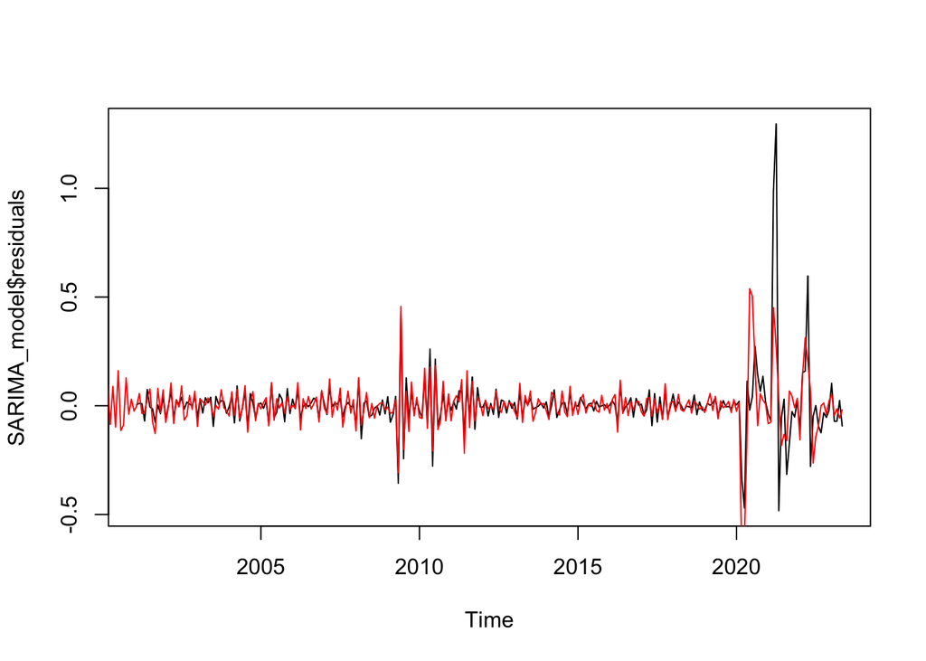

```r
plot(SARIMA_model$residuals)
lines(SARIMA_model2$residuals, col='red')
```